# The Data Science Challenge

Nome: Samir Tuffi Saliba Junior

```python
import pandas as pd
import numpy as np
import matplotlib.pyplot as plt
import seaborn as sns
```

```python
from datetime import datetime
dateparse = lambda x: datetime.strptime(x, '%Y-%m-%d %H:%M:%S')
```

Como os arquivos são grandes, vou apenas subir um dos anos em memória para fazer uma análise exploratória dos dados:

```python
df = pd.read_csv('2016.csv', parse_dates=['time'], date_parser=dateparse)
```

```python
df
```

|  | time | ca | unit | scp | station | linename | division | desc | entries | exits |
| --- | --- | --- | --- | --- | --- | --- | --- | --- | --- | --- |
| 0 | 2016-01-01 00:00:00 | A002 | R051 | 02-00-00 | 59 ST | NQR456 | BMT | REGULAR | 5477257.0 | 1848890.0 |
| 1 | 2016-01-01 00:00:00 | A002 | R051 | 02-00-01 | 59 ST | NQR456 | BMT | REGULAR | 5043156.0 | 1101348.0 |
| 2 | 2016-01-01 00:00:00 | A002 | R051 | 02-03-00 | 59 ST | NQR456 | BMT | REGULAR | 624029.0 | 2352788.0 |
| 3 | 2016-01-01 00:00:00 | A002 | R051 | 02-03-01 | 59 ST | NQR456 | BMT | REGULAR | 5006519.0 | 7904628.0 |
| 4 | 2016-01-01 00:00:00 | A002 | R051 | 02-03-02 | 59 ST | NQR456 | BMT | REGULAR | 4734413.0 | 6529179.0 |
| ... | ... | ... | ... | ... | ... | ... | ... | ... | ... | ... |
| 10130786 | 2016-12-31 23:53:08 | PTH11 | R545 | 00-04-00 | 14TH STREET | 1 | PTH | REGULAR | 1384.0 | 18140.0 |
| 10130787 | 2016-12-31 23:54:43 | PTH01 | R549 | 00-01-03 | NEWARK HW BMEBE | 1 | PTH | REGULAR | 81615.0 | 138104.0 |
| 10130788 | 2016-12-31 23:56:19 | PTH01 | R549 | 00-01-04 | NEWARK HW BMEBE | 1 | PTH | REGULAR | 115.0 | 44579.0 |
| 10130789 | 2016-12-31 23:57:15 | PTH16 | R550 | 01-01-05 | LACKAWANNA | 1 | PTH | REGULAR | 382645.0 | 210079.0 |
| 10130790 | 2016-12-31 23:59:00 | PTH03 | R552 | 00-00-01 | JOURNAL SQUARE | 1 | PTH | REGULAR | 26185.0 | 3960.0 |

10130791 rows × 10 columns

Para reduzir o escopo do problema, convém filtrar por uma das estações, como a de Times Square

```python
df = df[df['station'] == 'TIMES SQ-42 ST']
```

```python
df
```

|  | time | ca | unit | scp | station | linename | division | desc | entries | exits |
| --- | --- | --- | --- | --- | --- | --- | --- | --- | --- | --- |
| 48 | 2016-01-01 00:00:00 | A021 | R032 | 01-00-00 | TIMES SQ-42 ST | ACENQRS1237 | BMT | REGULAR | 5353323.0 | 6280609.0 |
| 49 | 2016-01-01 00:00:00 | A021 | R032 | 01-00-01 | TIMES SQ-42 ST | ACENQRS1237 | BMT | REGULAR | 962461.0 | 1165958.0 |
| 50 | 2016-01-01 00:00:00 | A021 | R032 | 01-00-02 | TIMES SQ-42 ST | ACENQRS1237 | BMT | REGULAR | 654087.0 | 683301.0 |
| 51 | 2016-01-01 00:00:00 | A021 | R032 | 01-00-03 | TIMES SQ-42 ST | ACENQRS1237 | BMT | REGULAR | 927818.0 | 466857.0 |
| 52 | 2016-01-01 00:00:00 | A021 | R032 | 01-00-04 | TIMES SQ-42 ST | ACENQRS1237 | BMT | REGULAR | 1005604.0 | 1661431.0 |
| ... | ... | ... | ... | ... | ... | ... | ... | ... | ... | ... |
| 10127810 | 2016-12-31 20:00:00 | R151 | R033 | 00-00-04 | TIMES SQ-42 ST | 1237ACENQRSW | IRT | REGULAR | 14395407.0 | 22098220.0 |
| 10127811 | 2016-12-31 20:00:00 | R151 | R033 | 00-00-05 | TIMES SQ-42 ST | 1237ACENQRSW | IRT | REGULAR | 35063752.0 | 86354008.0 |
| 10127812 | 2016-12-31 20:00:00 | R151 | R033 | 00-00-06 | TIMES SQ-42 ST | 1237ACENQRSW | IRT | REGULAR | 6126759.0 | 7489366.0 |
| 10127813 | 2016-12-31 20:00:00 | R151 | R033 | 00-00-07 | TIMES SQ-42 ST | 1237ACENQRSW | IRT | REGULAR | 18457304.0 | 13038180.0 |
| 10127814 | 2016-12-31 20:00:00 | R151 | R033 | 00-00-08 | TIMES SQ-42 ST | 1237ACENQRSW | IRT | REGULAR | 5209544.0 | 1660272.0 |

111901 rows × 10 columns

Como a medição é acumulativa, para sabermos o tráfico é preciso subtrair com a medição anterior. Para isso, pode-se agrupar os dados por catraca e subtrair com o dado anterior.

```python
df['n_in'] = df.groupby(['station', 'unit', 'ca', 'scp'])['entries'].diff()
df['n_out'] = df.groupby(['station', 'unit', 'ca', 'scp'])['exits'].diff()
df['n_in'] = abs(df['n_in'])
df['n_out'] = abs(df['n_out'])
```

```python
df['traffic'] = df['n_in'] + df['n_out']
```

Entretanto, pode-se perceber que o uso da função .diff, embora seja prático, subtraiu linhas de catracas diferentes, gerando dados exorbitantes:

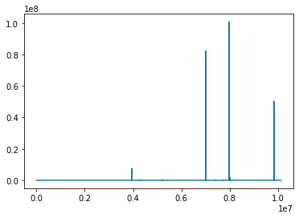

```python
df.traffic.plot()
```

Seria interessante, então, ver a distribuição dos dados e remover outliers:

```python
df.traffic.describe()
```

```
count    1.118510e+05
mean     2.713414e+03
std      4.177777e+05
min      0.000000e+00
25%      1.260000e+02
50%      3.660000e+02
75%      8.550000e+02
max      1.008156e+08
Name: traffic, dtype: float64
```

Pode-se perceber que usando o quantil de 99,9% é possível obter uma distribuição razoável dos dados, removendo todos os outliers exorbitantes:

```python
df.traffic.quantile(.999)
```

```
2392.0
```

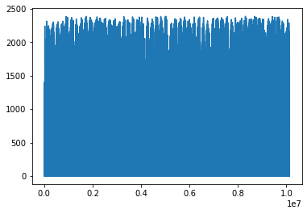

```python
df[df.traffic < df.traffic.quantile(.999)].traffic.plot()
```

```python
df = df[df.traffic < df.traffic.quantile(.999)]
```

```python
df['date'] = df['time'].dt.date
df['weekday'] = df['time'].dt.weekday
df['month'] = df['time'].dt.month
```

```python
df = df.groupby(['date', 'station', 'unit', 'ca', 'scp'])\
        .agg(
            {'n_in': 'mean',
             'n_out': 'mean',
             'traffic': 'mean',
             'weekday': 'first',
             'month': 'first'
            }
        )
```

Como são medições de 4 em 4 horas em cada catraca e temos a média das medições - uma opção é multiplicar a média por 6 para aproximarmos ao fluxo real.

```python
df['n_in'] *= 6
df['n_out'] *= 6
df['traffic'] *= 6
```

```python
df.reset_index(inplace=True)
```

Podemos então ver como são os dados diários:

```python
df[['date', 'traffic', 'n_in', 'n_out']]\
.groupby('date').sum().describe()
```

|  | traffic | n_in | n_out |
| --- | --- | --- | --- |
| count | 366.000000 | 366.000000 | 366.000000 |
| mean | 162489.587477 | 85135.922552 | 77353.664925 |
| std | 30186.876014 | 18442.374562 | 12987.539735 |
| min | 32211.000000 | 14143.000000 | 18068.000000 |
| 25% | 137533.400000 | 66108.118561 | 67615.035714 |
| 50% | 167447.000000 | 90984.566667 | 80102.900000 |
| 75% | 190064.964286 | 100653.562500 | 88758.482143 |
| max | 206474.800000 | 111964.000000 | 98807.000000 |

Temos uma média diária de tráfego de 162.489 pessoas.

Podemos imaginar que há uma correlação entre fluxo de pessoas no transporte público e se a data em questão é ou não feriado. Assim, pode-se obter se uma data foi feriado nos EUA, especificamente no estado de NY, para adicionarmos ao dataset:

```python
import holidays
us_holidays = holidays.UnitedStates(state='NY')

def feriado_wrapper(x):
    if us_holidays.get(x) == None:
        return False
    return True
```

```python
df['feriado'] = df['date'].apply(lambda x: feriado_wrapper(x))
```

Podemos ver então a relação temporal com o movimento, como movimento por dias do ano, meses ou por dias da semana:

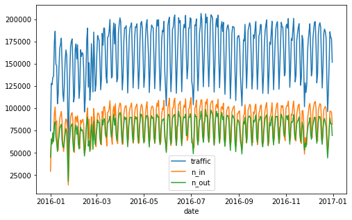

```python
df[['date', 'traffic', 'n_in', 'n_out']]\
.groupby('date').sum().plot.line(figsize=(8,5))
```

Plotando apenas dois meses, junho e julho, por exemplo, é mais fácil de visualizar a sazonalidade do tráfego:

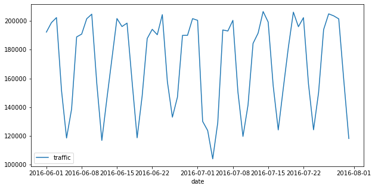

```python
df[df['month'].isin([6,7])]\
[['traffic', 'date']]\
.groupby('date').sum().plot.line(figsize=(10,5))
```

```python
df[['date', 'traffic', 'n_in', 'n_out']]\
.groupby('date').sum()['traffic'].mean()
```

```
162489.58747727692
```

Movimento por mês:

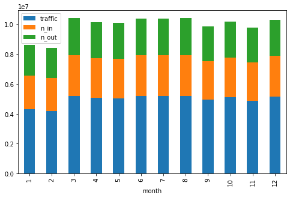

```python
df[['month', 'traffic', 'n_in', 'n_out']]\
.groupby('month').sum().plot.bar(stacked=True,figsize=(8,5))
```

E por dias da semana - em laranja, os dias de final de semana.

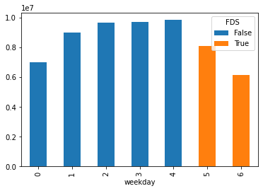

```python
df_exib = df[['weekday', 'traffic']]\
.groupby('weekday').sum()

df_exib.reset_index(inplace=True)
df_exib['FDS'] = df_exib['weekday'].apply(lambda x: x>4)

df_exib.pivot(
    index='weekday',columns='FDS',values='traffic')\
   .plot.bar(stacked=True)
```

Em destaque, um dos dias que foi feriado, 4 de julho, dia da independência americana, justamente o dia de menor tráfego na estação para o mês de julho:

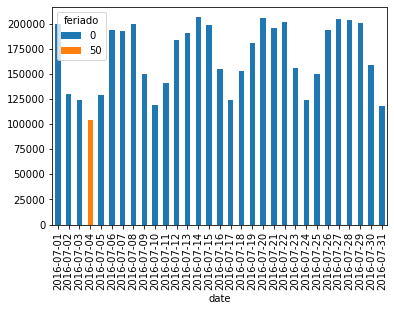

```python
df_exib = df[df['month']==7][['traffic', 'date', 'feriado', 'weekday']]\
.groupby('date').sum()

df_exib.reset_index(inplace=True)

df_exib.pivot(index='date',
              columns=['feriado'],
              values='traffic')\
   .plot.bar(stacked=True)
```

E como os feriados alteram o fluxo de pessoas - vale considerar que a Times Square é uma estação turística, que talvez seja **menos** afetada que outras estações em feriados.

```python
data = df.groupby(['date'])\
        .agg(
            {'n_in': 'sum',
             'n_out': 'sum',
             'traffic': 'sum',
             'weekday': 'first',
             'month':'first',
             'feriado':'first'
            }
        )
```

```python
data.groupby('feriado').mean()
```

| feriado | n_in | n_out | traffic | weekday | month |
| --- | --- | --- | --- | --- | --- |
| False | 85878.385989 | 77942.404427 | 163820.790416 | 3.056657 | 6.487252 |
| True | 64975.184615 | 61367.123077 | 126342.307692 | 1.692308 | 7.230769 |

Temos a média diária de 163.820 pessoas para dias normais e 126.342 para feriados.

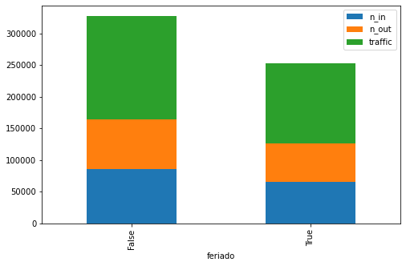

```python
data[['feriado', 'n_in', 'n_out', 'traffic']].groupby('feriado').mean().plot.bar(figsize=(8,5), stacked=True)
```

```python
data[['traffic', 'month', 'weekday', 'feriado']].corr()
```

|  | traffic | month | weekday | feriado |
| --- | --- | --- | --- | --- |
| traffic | 1.000000 | 0.169215 | -0.207555 | -0.230110 |
| month | 0.169215 | 1.000000 | -0.002592 | 0.039874 |
| weekday | -0.207555 | -0.002592 | 1.000000 | -0.126393 |
| feriado | -0.230110 | 0.039874 | -0.126393 | 1.000000 |

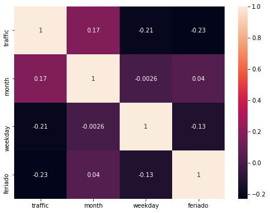

```python
plt.figure(figsize=(8, 6))
sns.heatmap(
    data[['traffic', 'month', 'weekday', 'feriado']].corr(), annot=True)
```

Inicialmente, pode-se treinar algoritmo regressor pra ver os resultados iniciais:

Nesse caso, usarei o **XGBoost** para regressão, um algoritmo baseado em árvores e na estratégia de **boosting**, na qual várias árvores de decisão são treinadas sequencialmente e buscam reduzir o erro da árvore anterior.

```python
data.reset_index(inplace=True)
```

```python
X, y = data[['weekday', 'month', 'feriado']], data['traffic']
```

```python
from sklearn.model_selection import KFold
from sklearn.preprocessing import MinMaxScaler
from xgboost import XGBRegressor
from sklearn.metrics import mean_absolute_percentage_error


kf = KFold(n_splits=10)
mape_m1 = []

for train_index, test_index in kf.split(data):
    X_train, X_test = X.iloc[train_index], X.iloc[test_index]
    y_train, y_test = y[train_index], y[test_index]

    scaler = MinMaxScaler()

    X_train = scaler.fit_transform(X_train)
    X_test = scaler.transform(X_test)

    model = XGBRegressor()
    model.fit(X_train,y_train)

    y_pred = model.predict(X_test)
    mape_it = mean_absolute_percentage_error(y_test, y_pred)
    mape_m1.append(mape_it)
```

Plotando o último conjunto y_test e a saída do modelo:

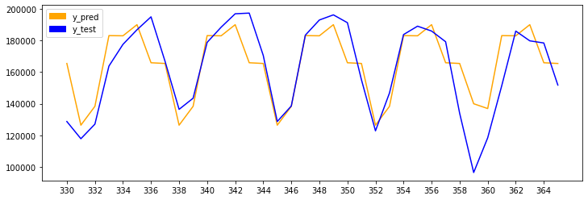

```python
import math
import matplotlib.patches as mpatches

t = test_index

plt.figure(figsize=(12, 4))
plt.plot(t, y_pred, 'orange')
plt.plot(t, y_test, 'blue')

orange = mpatches.Patch(color='orange', label='y_pred')
blu = mpatches.Patch(color='blue', label='y_test')

plt.xticks(np.arange(min(t), max(t)+1, 2))
plt.legend(handles=[orange, blu])
plt.show()
```

Percebe-se que o regressor se saiu razoavelmente bem, embora tenha subestimado um pouco nos picos semanais desse mês. Um detalhe importante é como o modelo não previu a grande queda no **Natal**. Isso poderia ser corrigido caso o modelo fosse treinado com dados de vários anos diferentes, capturando melhor a variação em datas atípicas. Poderia ser feita, por exemplo, uma melhor distinção entre os feriados em vez de uma variábel booleana (verdadeiro, falso).

Uma possibilidade de melhorar o desempenho do modelo seria criando novas features que possam trazer mais informação para o modelo. Uma delas, por exemplo, pode ser a medição do fluxo no dia anterior.

```python
data['yesterday-traffic'] = data['traffic'].shift()
```

```python
data
```

|  | date | n_in | n_out | traffic | weekday | month | feriado | yesterday-traffic |
| --- | --- | --- | --- | --- | --- | --- | --- | --- |
| 0 | 2016-01-01 | 29467.200000 | 45300.000000 | 74767.200000 | 4 | 1 | True | NaN |
| 1 | 2016-01-02 | 62508.000000 | 65479.000000 | 127987.000000 | 5 | 1 | False | 74767.200000 |
| 2 | 2016-01-03 | 66605.800000 | 60018.400000 | 126624.200000 | 6 | 1 | False | 127987.000000 |
| 3 | 2016-01-04 | 62014.000000 | 72768.000000 | 134782.000000 | 0 | 1 | False | 126624.200000 |
| 4 | 2016-01-05 | 73428.083333 | 62767.583333 | 136195.666667 | 1 | 1 | False | 134782.000000 |
| ... | ... | ... | ... | ... | ... | ... | ... | ... |
| 361 | 2016-12-27 | 74897.000000 | 76415.000000 | 151312.000000 | 1 | 12 | False | 118402.000000 |
| 362 | 2016-12-28 | 96869.000000 | 89035.400000 | 185904.400000 | 2 | 12 | False | 151312.000000 |
| 363 | 2016-12-29 | 96842.714286 | 82889.400000 | 179732.114286 | 3 | 12 | False | 185904.400000 |
| 364 | 2016-12-30 | 95620.200000 | 82744.000000 | 178364.200000 | 4 | 12 | False | 179732.114286 |
| 365 | 2016-12-31 | 82213.400000 | 69528.400000 | 151741.800000 | 5 | 12 | False | 178364.200000 |

366 rows × 8 columns

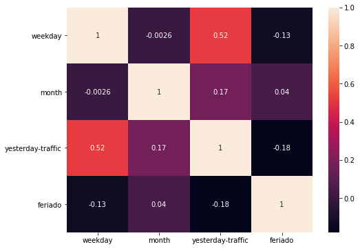

```python
import seaborn as sns
from sklearn.preprocessing import MinMaxScaler

plt.figure(figsize=(8, 6))
sns.heatmap(
    data[['weekday', 'month',  'yesterday-traffic', 'feriado']].corr(), annot=True)
```

```python
X,y = data[['weekday', 'month', 'feriado', 'yesterday-traffic']], data['traffic']
```

```python
mape_m2 = []

for train_index, test_index in kf.split(data):
    X_train, X_test = X.iloc[train_index], X.iloc[test_index]
    y_train, y_test = y[train_index], y[test_index]

    scaler = MinMaxScaler()

    X_train = scaler.fit_transform(X_train)
    X_test = scaler.transform(X_test)

    model = XGBRegressor()
    model.fit(X_train,y_train)

    y_pred = model.predict(X_test)
    mape_it = mean_absolute_percentage_error(y_test, y_pred)
    mape_m2.append(mape_it)
```

```python
media_m1 = sum(mape_m1)/len(mape_m1)
media_m2 = sum(mape_m2)/len(mape_m2)
diff = media_m2 - media_m1
print(f'{media_m1 = }\n{media_m2 = }\n{diff = }')
```

```
media_m1 = 0.07900776056333621
media_m2 = 0.06470214538631096
diff = -0.01430561517702525
```

Podemos ver que a média do erro diminuiu, ou seja, houve uma melhora no desempenho do modelo.

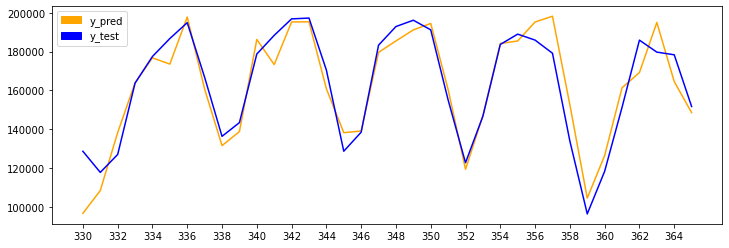

```python
t = test_index

plt.figure(figsize=(12, 4))
plt.plot(t, y_pred, 'orange')
plt.plot(t, y_test, 'blue')

orange = mpatches.Patch(color='orange', label='y_pred')
blu = mpatches.Patch(color='blue', label='y_test')

plt.xticks(np.arange(min(t), max(t)+1, 2))
plt.legend(handles=[orange, blu])
plt.show()
```

Sem dúvidas, o modelo parece melhor ajustado. Entretanto, é necessário destacar que este modelo fez previsões usando dados **reais** do dia anterior. Não se trata de uma previsão contínua de 1 mês no futuro; e sim de repetidas previsões de 1 dia no futuro, usando dados do dia anterior para cada previsão.  
Portanto, esse modelo depende de dados do dia anterior; **diferentemente** do primeiro modelo testado, que apenas utilizava o dia da semana, o mês e se a data é feriado - todos dados podem ser obtidos com total antecedência.

Uma análise interessante seria testar como o segundo modelo responderia para a previsão de 1 mês futuro seguido, no caso de dezembro, sem utilizar dados deste mês. Dessa forma, para o valor de fluxo no dia anterior seria a previsão do modelo para o dia anterior; e não o dado real.

```python
mape_m3 = []
for train_index, test_index in kf.split(data):
    X_train, X_test = X.iloc[train_index], X.iloc[test_index]
    y_train, y_test = y[train_index], y[test_index]

    scaler = MinMaxScaler()

    X_train = pd.DataFrame(scaler.fit_transform(X_train),
                           columns=X.columns)
    X_test = pd.DataFrame( scaler.transform(X_test),
                           columns=X.columns)

    model = XGBRegressor()
    model.fit(X_train,y_train)

    y_pred = []
    for idx, x in X_test.iterrows():
        y_pred_i = model.predict(
            pd.DataFrame(np.array([x.values]),
                         columns=X.columns)

        )
        if idx<37: X_test.loc[idx+1, 'yesterday-traffic'] = y_pred_i
        y_pred.append(y_pred_i)

    mape_it = mean_absolute_percentage_error(y_test, y_pred)
    mape_m3.append(mape_it)
```

```python
media_m1 = sum(mape_m1)/len(mape_m1)
media_m3 = sum(mape_m3)/len(mape_m3)
diff = media_m3 - media_m1
print(f'{media_m3 = }\n{media_m1 = }\n{diff = }')
```

```
media_m3 = 0.13323931840365594
media_m1 = 0.07900776056333621
diff = 0.05423155784031973
```

Podemos ver que o modelo, no cenário de fazer a previsão para 1 mês seguido sem informações, teve pior desemepenho em relação ao primeiro.

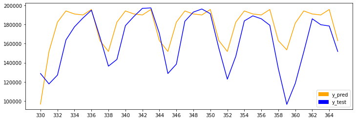

```python
t = test_index

plt.figure(figsize=(12, 4))
plt.plot(t, y_pred, 'orange')
plt.plot(t, y_test, 'blue')

orange = mpatches.Patch(color='orange', label='y_pred')
blu = mpatches.Patch(color='blue', label='y_test')

plt.xticks(np.arange(min(t), max(t)+1, 2))
plt.legend(handles=[orange, blu])
plt.show()
```

A escolha entre os modelos dependeria do cenário desejado. Por exemplo, para prever datas muito ao futuro, o primeiro modelo apresentou melhores resultados. Entretanto, se a previsão for para o próximo dia, amanhã, e tivermos os dados de hoje, o segundo modelo apresenta melhor resultado.

Outra estratégia além da regressão é utilizar um modelo de série temporal.

```python
data
```

|  | date | n_in | n_out | traffic | weekday | month | feriado | yesterday-traffic |
| --- | --- | --- | --- | --- | --- | --- | --- | --- |
| 0 | 2016-01-01 | 29467.200000 | 45300.000000 | 74767.200000 | 4 | 1 | True | NaN |
| 1 | 2016-01-02 | 62508.000000 | 65479.000000 | 127987.000000 | 5 | 1 | False | 74767.200000 |
| 2 | 2016-01-03 | 66605.800000 | 60018.400000 | 126624.200000 | 6 | 1 | False | 127987.000000 |
| 3 | 2016-01-04 | 62014.000000 | 72768.000000 | 134782.000000 | 0 | 1 | False | 126624.200000 |
| 4 | 2016-01-05 | 73428.083333 | 62767.583333 | 136195.666667 | 1 | 1 | False | 134782.000000 |
| ... | ... | ... | ... | ... | ... | ... | ... | ... |
| 361 | 2016-12-27 | 74897.000000 | 76415.000000 | 151312.000000 | 1 | 12 | False | 118402.000000 |
| 362 | 2016-12-28 | 96869.000000 | 89035.400000 | 185904.400000 | 2 | 12 | False | 151312.000000 |
| 363 | 2016-12-29 | 96842.714286 | 82889.400000 | 179732.114286 | 3 | 12 | False | 185904.400000 |
| 364 | 2016-12-30 | 95620.200000 | 82744.000000 | 178364.200000 | 4 | 12 | False | 179732.114286 |
| 365 | 2016-12-31 | 82213.400000 | 69528.400000 | 151741.800000 | 5 | 12 | False | 178364.200000 |

366 rows × 8 columns

```python
data.set_index('date')
```

| date | n_in | n_out | traffic | weekday | month | feriado | yesterday-traffic |
| --- | --- | --- | --- | --- | --- | --- | --- |
| 2016-01-01 | 29467.200000 | 45300.000000 | 74767.200000 | 4 | 1 | True | NaN |
| 2016-01-02 | 62508.000000 | 65479.000000 | 127987.000000 | 5 | 1 | False | 74767.200000 |
| 2016-01-03 | 66605.800000 | 60018.400000 | 126624.200000 | 6 | 1 | False | 127987.000000 |
| 2016-01-04 | 62014.000000 | 72768.000000 | 134782.000000 | 0 | 1 | False | 126624.200000 |
| 2016-01-05 | 73428.083333 | 62767.583333 | 136195.666667 | 1 | 1 | False | 134782.000000 |
| ... | ... | ... | ... | ... | ... | ... | ... |
| 2016-12-27 | 74897.000000 | 76415.000000 | 151312.000000 | 1 | 12 | False | 118402.000000 |
| 2016-12-28 | 96869.000000 | 89035.400000 | 185904.400000 | 2 | 12 | False | 151312.000000 |
| 2016-12-29 | 96842.714286 | 82889.400000 | 179732.114286 | 3 | 12 | False | 185904.400000 |
| 2016-12-30 | 95620.200000 | 82744.000000 | 178364.200000 | 4 | 12 | False | 179732.114286 |
| 2016-12-31 | 82213.400000 | 69528.400000 | 151741.800000 | 5 | 12 | False | 178364.200000 |

366 rows × 7 columns

```python
data['date'] = pd.to_datetime(data['date'])
data.set_index('date', inplace=True)
```

Podemos decompor a série temporal em tendência, resíduo e variações sazonais:

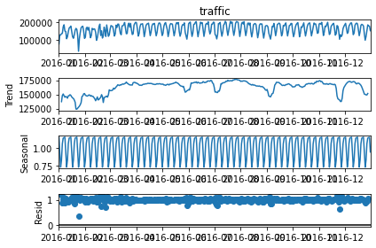

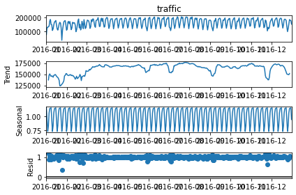

```python
from statsmodels.tsa.seasonal import seasonal_decompose

decomposicao = seasonal_decompose(data['traffic'],
                            model ='multiplicative')


decomposicao.plot()
```

Pode-se treinar também algoritmos de séries temporais, como o ARIMA, para a predição do fluxo de pessoas.  
Nesse caso, usarei o SARIMAX, que é uma extensão do algoritmo ARIMA adicionados os componentes de sazonalidade e componentes externos, como os feriados.

```python
from pmdarima import auto_arima

import warnings
warnings.filterwarnings("ignore")

exog_feriados = np.asarray(data['feriado'].astype(int)).reshape(-1, 1)

# Fit autoarima para o dataset encontrando os melhores parâmetros
fit = auto_arima(data['traffic'], start_p = 1, start_q = 1,
                          X=exog_feriados,
                          max_p = 4, max_q = 4, m = 7,
                          start_P = 0, seasonal = True,
                          d = None, D = 1, trace = True,
                          error_action ='ignore',
                          suppress_warnings = True,
                          with_intercept=True,
                          stepwise = False
                         )

fit.summary()
```

```
 ARIMA(0,0,0)(0,1,0)[7] intercept   : AIC=8025.466, Time=0.02 sec
 ARIMA(0,0,0)(0,1,1)[7] intercept   : AIC=7993.178, Time=0.13 sec
 ARIMA(0,0,0)(0,1,2)[7] intercept   : AIC=7992.862, Time=0.60 sec
 ARIMA(0,0,0)(1,1,0)[7] intercept   : AIC=7997.797, Time=0.11 sec
 ARIMA(0,0,0)(1,1,1)[7] intercept   : AIC=7992.321, Time=0.21 sec
 ARIMA(0,0,0)(1,1,2)[7] intercept   : AIC=7994.316, Time=0.99 sec
 ARIMA(0,0,0)(2,1,0)[7] intercept   : AIC=7995.766, Time=0.40 sec
 ARIMA(0,0,0)(2,1,1)[7] intercept   : AIC=7994.313, Time=0.77 sec
 ARIMA(0,0,0)(2,1,2)[7] intercept   : AIC=7993.268, Time=1.32 sec
 ARIMA(0,0,1)(0,1,0)[7] intercept   : AIC=7996.860, Time=0.05 sec
 ARIMA(0,0,1)(0,1,1)[7] intercept   : AIC=7938.440, Time=0.16 sec
 ARIMA(0,0,1)(0,1,2)[7] intercept   : AIC=7938.980, Time=0.65 sec
 ARIMA(0,0,1)(1,1,0)[7] intercept   : AIC=7950.635, Time=0.12 sec
 ARIMA(0,0,1)(1,1,1)[7] intercept   : AIC=7938.911, Time=0.17 sec
 ARIMA(0,0,1)(1,1,2)[7] intercept   : AIC=7940.911, Time=1.10 sec
 ARIMA(0,0,1)(2,1,0)[7] intercept   : AIC=7944.050, Time=0.44 sec
 ARIMA(0,0,1)(2,1,1)[7] intercept   : AIC=7940.844, Time=0.76 sec
 ARIMA(0,0,1)(2,1,2)[7] intercept   : AIC=7941.102, Time=2.81 sec
 ARIMA(0,0,2)(0,1,0)[7] intercept   : AIC=7998.215, Time=0.09 sec
 ARIMA(0,0,2)(0,1,1)[7] intercept   : AIC=7929.891, Time=0.57 sec
 ARIMA(0,0,2)(0,1,2)[7] intercept   : AIC=7931.111, Time=0.73 sec
 ARIMA(0,0,2)(1,1,0)[7] intercept   : AIC=7945.364, Time=0.15 sec
 ARIMA(0,0,2)(1,1,1)[7] intercept   : AIC=7931.049, Time=0.53 sec
 ARIMA(0,0,2)(1,1,2)[7] intercept   : AIC=7931.744, Time=2.71 sec
 ARIMA(0,0,2)(2,1,0)[7] intercept   : AIC=7937.255, Time=0.55 sec
 ARIMA(0,0,2)(2,1,1)[7] intercept   : AIC=7933.027, Time=0.94 sec
 ARIMA(0,0,3)(0,1,0)[7] intercept   : AIC=7991.439, Time=0.12 sec
 ARIMA(0,0,3)(0,1,1)[7] intercept   : AIC=7910.606, Time=0.66 sec
 ARIMA(0,0,3)(0,1,2)[7] intercept   : AIC=7912.476, Time=0.87 sec
 ARIMA(0,0,3)(1,1,0)[7] intercept   : AIC=7929.816, Time=0.19 sec
 ARIMA(0,0,3)(1,1,1)[7] intercept   : AIC=7912.455, Time=0.73 sec
 ARIMA(0,0,3)(2,1,0)[7] intercept   : AIC=7920.875, Time=0.68 sec
 ARIMA(0,0,4)(0,1,0)[7] intercept   : AIC=7990.445, Time=0.16 sec
 ARIMA(0,0,4)(0,1,1)[7] intercept   : AIC=7911.429, Time=0.70 sec
 ARIMA(0,0,4)(1,1,0)[7] intercept   : AIC=7930.772, Time=0.20 sec
 ARIMA(1,0,0)(0,1,0)[7] intercept   : AIC=7994.399, Time=0.04 sec
 ARIMA(1,0,0)(0,1,1)[7] intercept   : AIC=7909.421, Time=0.21 sec
 ARIMA(1,0,0)(0,1,2)[7] intercept   : AIC=7911.410, Time=0.67 sec
 ARIMA(1,0,0)(1,1,0)[7] intercept   : AIC=7934.456, Time=0.15 sec
 ARIMA(1,0,0)(1,1,1)[7] intercept   : AIC=7911.417, Time=0.23 sec
```

[output cut: 42 more lines]

```
 ARIMA(3,0,0)(0,1,2)[7] intercept   : AIC=7894.412, Time=0.89 sec
 ARIMA(3,0,0)(1,1,0)[7] intercept   : AIC=7919.706, Time=0.55 sec
 ARIMA(3,0,0)(1,1,1)[7] intercept   : AIC=7894.416, Time=0.82 sec
 ARIMA(3,0,0)(2,1,0)[7] intercept   : AIC=7907.131, Time=0.77 sec
 ARIMA(3,0,1)(0,1,0)[7] intercept   : AIC=7992.115, Time=0.24 sec
 ARIMA(3,0,1)(0,1,1)[7] intercept   : AIC=7867.298, Time=1.33 sec
 ARIMA(3,0,1)(1,1,0)[7] intercept   : AIC=7920.192, Time=0.98 sec
 ARIMA(3,0,2)(0,1,0)[7] intercept   : AIC=7959.616, Time=0.63 sec
 ARIMA(4,0,0)(0,1,0)[7] intercept   : AIC=7986.959, Time=0.14 sec
 ARIMA(4,0,0)(0,1,1)[7] intercept   : AIC=7891.737, Time=0.33 sec
 ARIMA(4,0,0)(1,1,0)[7] intercept   : AIC=7920.284, Time=0.59 sec
 ARIMA(4,0,1)(0,1,0)[7] intercept   : AIC=7986.913, Time=0.24 sec

Best model:  ARIMA(3,0,1)(0,1,1)[7] intercept
Total fit time: 68.129 seconds
```

SARIMAX Results

| Dep. Variable: | y | No. Observations: | 366 |
| --- | --- | --- | --- |
| Model: | SARIMAX(3, 0, 1)x(0, 1, 1, 7) | Log Likelihood | -3925.649 |
| Date: | Tue, 10 Aug 2021 | AIC | 7867.298 |
| Time: | 00:24:33 | BIC | 7898.365 |
| Sample: | 0 | HQIC | 7879.652 |
|  | - 366 |  |  |
| Covariance Type: | opg |  |  |

|  | coef | std err | z | P>\|z\| | [0.025 | 0.975] |
| --- | --- | --- | --- | --- | --- | --- |
| intercept | 1.2487 | 50.227 | 0.025 | 0.980 | -97.194 | 99.692 |
| x1 | -2.014e+04 | 3752.043 | -5.367 | 0.000 | -2.75e+04 | -1.28e+04 |
| ar.L1 | 1.1957 | 0.075 | 16.034 | 0.000 | 1.050 | 1.342 |
| ar.L2 | -0.3001 | 0.106 | -2.841 | 0.004 | -0.507 | -0.093 |
| ar.L3 | 0.0876 | 0.078 | 1.128 | 0.260 | -0.065 | 0.240 |
| ma.L1 | -0.7967 | 0.042 | -19.085 | 0.000 | -0.879 | -0.715 |
| ma.S.L7 | -0.8426 | 0.063 | -13.476 | 0.000 | -0.965 | -0.720 |
| sigma2 | 2.612e+08 | 0.294 | 8.9e+08 | 0.000 | 2.61e+08 | 2.61e+08 |

| Ljung-Box (L1) (Q): | 0.03 | Jarque-Bera (JB): | 2067.35 |
| --- | --- | --- | --- |
| Prob(Q): | 0.86 | Prob(JB): | 0.00 |
| Heteroskedasticity (H): | 0.62 | Skew: | -1.93 |
| Prob(H) (two-sided): | 0.01 | Kurtosis: | 14.10 |

Warnings:  
[1] Covariance matrix calculated using the outer product of gradients (complex-step).  
[2] Covariance matrix is singular or near-singular, with condition number 6.64e+24. Standard errors may be unstable.

```python
# Split data into train / test sets

train = data[['traffic', 'feriado']].iloc[:len(data)-30]
test = data[['traffic', 'feriado']].iloc[len(data)-30:]
```

```python
from statsmodels.tsa.statespace.sarimax import SARIMAX

model = SARIMAX(endog= train['traffic'],
                exog = train['feriado'].astype(int),
                order = (3, 0, 1),
                seasonal_order =(0, 1, 1, 7))

result = model.fit()
result.summary()
```

SARIMAX Results

| Dep. Variable: | traffic | No. Observations: | 336 |
| --- | --- | --- | --- |
| Model: | SARIMAX(3, 0, 1)x(0, 1, 1, 7) | Log Likelihood | -3613.510 |
| Date: | Tue, 10 Aug 2021 | AIC | 7241.020 |
| Time: | 00:24:33 | BIC | 7267.593 |
| Sample: | 01-01-2016 | HQIC | 7251.621 |
|  | - 12-01-2016 |  |  |
| Covariance Type: | opg |  |  |

|  | coef | std err | z | P>\|z\| | [0.025 | 0.975] |
| --- | --- | --- | --- | --- | --- | --- |
| feriado | -1.945e+04 | 3089.945 | -6.295 | 0.000 | -2.55e+04 | -1.34e+04 |
| ar.L1 | 0.0739 | 0.292 | 0.253 | 0.800 | -0.499 | 0.647 |
| ar.L2 | 0.1898 | 0.136 | 1.392 | 0.164 | -0.077 | 0.457 |
| ar.L3 | 0.2179 | 0.056 | 3.862 | 0.000 | 0.107 | 0.328 |
| ma.L1 | 0.3250 | 0.304 | 1.069 | 0.285 | -0.271 | 0.921 |
| ma.S.L7 | -0.5752 | 0.050 | -11.566 | 0.000 | -0.673 | -0.478 |
| sigma2 | 2.515e+08 | 0.318 | 7.9e+08 | 0.000 | 2.52e+08 | 2.52e+08 |

| Ljung-Box (L1) (Q): | 0.00 | Jarque-Bera (JB): | 1243.03 |
| --- | --- | --- | --- |
| Prob(Q): | 0.97 | Prob(JB): | 0.00 |
| Heteroskedasticity (H): | 0.49 | Skew: | -1.33 |
| Prob(H) (two-sided): | 0.00 | Kurtosis: | 12.14 |

Warnings:  
[1] Covariance matrix calculated using the outer product of gradients (complex-step).  
[2] Covariance matrix is singular or near-singular, with condition number 4.35e+23. Standard errors may be unstable.

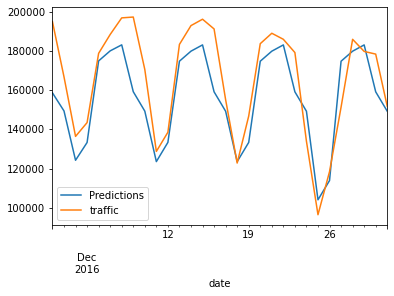

```python
start = len(train)
end = len(train) + len(test) - 1

predictions = result.predict(start,
                             end,
                             exog=test['feriado'].astype(int),
                             typ = 'levels').rename("Predictions")

predictions.plot(legend = True)
test['traffic'].plot(legend = True)
plt.show()
```

```python
media_m1
```

```
0.07900776056333621
```

```python
media_m3
```

```
0.13323931840365594
```

```python
mean_absolute_percentage_error(test['traffic'], predictions)
```

```
0.07506399138998159
```

Como podemos ver, dado o erro, este último modelo foi o melhor entre os 3 considerados (excluindo-se o modelo que precisa do dia anterior). Além disso, a diferença da previsão para o fluxo real no Natal foi consideravelmente menor.

Como próximos passos, seria possível tentar extrair mais features dos dados e testar outros modelos, além de usar dados de vários anos para o treino. Uma possibilidade seria usar a média da semana anterior para o modelo com os dados do dia anterior - tornaria o modelo mais "prático" para cenários reais.